# CVIS Data Report - LOWER FRASER RIVER_FA_0.3

## About

This report explores climate vulnerability indicator data for the selected conservation unit (CU) in the Fraser Basin. The report displays maps and summaries of indicator data for the CU.

### Sections

- **Overview:** Summary of all climate vulnerability indicators for the selected conservation unit.
- **Demographics:** Conservation status and recent spawner abundance
- **Timing:** Life stage timing for the CU and indicator time periods
- **Spawning and Rearing:** Environmental change to streams, cumulative threats to stream habitats, and freshwater residency times
- **Migration:** Changes to stream temperatures and flows during upstream migration, and distance to spawning sites
- **Marine:** Changes to sea surface temperature and cumulative impacts to nearshore marine habitat

### Default Parameters

All indicators are displayed using:

- **RCP 4.5:** Representative Concentration Pathway 4.5 (moderate emissions scenario)
- **Time Period:** Mid-Century (2041-2060)

### Data Quality

#### ⚠️ Draft Data Disclaimer

**DRAFT - Not for further distribution without permission of the authors**

This data and analysis are preliminary and subject to change. The indicators presented here are under active development and have not been peer-reviewed. Results should be interpreted with caution and are intended for exploratory analysis only. Please contact the authors before citing or using this information in any formal capacity.

## Overview

### All Climate Vulnerability Indicators

Summary of all climate vulnerability indicators for the selected conservation unit. Green shading indicates values below species average (lower risk), while red indicates values above species average (higher risk).

#### CK-03 Indicator Summary, RCP 45, Period 3

| Indicator Type | Indicator Code | CU score | Species score | All Species score | Mean | Q10 | Q90 | Species Mean | All Species Mean |
| --- | --- | --- | --- | --- | --- | --- | --- | --- | --- |
| Demographics | CUstatus | 0.5 | 0.625 | NA | NA | NA | NA | NA | NA |
| Demographics | CUnmat | 0 | 0.533639404656424 | NA | 66871 | NA | NA | 20903.25 | NA |
| Genetics | genoff | NA | 0.445284953910768 | 0.548349856796742 | NA | NA | NA | 0.0171555219047619 | 0.0187845448382353 |
| Genetics | hetzyg | NA | 0.60236577926875 | 0.38793408041874 | NA | NA | NA | 0.243526744065476 | 0.246394835791667 |
| Freshwater Spawning and Rearing | fwres | 0.666666666666667 | 0.907407407407407 | NA | 202.8023337 | NA | NA | 503.952262805556 | NA |
| Freshwater Spawning and Rearing | CT | 0.752964549109743 | 0.559652064481243 | 0.543535592328396 | 1.93216304625762 | NA | NA | 1.43610883013145 | 1.41211920717931 |
| Freshwater Spawning and Rearing | favchange | 0 | 0.0321392670873897 | 0.133591374000896 | 0.0216523034831287 | NA | NA | 0.0925428024977514 | 0.0402310567733335 |
| Freshwater Spawning and Rearing | tw8proj | 0.197801920928436 | 0.176716329071034 | 0.163784202653904 | 17.1439386494513 | 16.6208460112938 | 17.6497394170331 | 16.1571427782495 | 15.9556107048002 |
| Freshwater Spawning and Rearing | tw8rate | 0.376108415391892 | 0.522059840726655 | 0.478958724401976 | 0.492453763179364 | 0.40527165681978 | 0.576753891109658 | 0.525095371348869 | 0.515570735747484 |
| Freshwater Spawning and Rearing | lowQpdelta | 0.68777134301501 | 0.468146277645113 | 0.481953071877427 | -0.3926900670941 | -0.645626584367443 | -0.158254811926748 | -0.311088454878177 | -0.317372601020936 |

[output cut: 7 more lines]

## Demographics

### Demographic Indicators Summary

Recent conservation status and number of mature individuals indicator values.

| Indicator Type | Indicator Code | CU score | Species score | All Species score | Mean | Q10 | Q90 | Species Mean | All Species Mean |
| --- | --- | --- | --- | --- | --- | --- | --- | --- | --- |
| Demographics | CUstatus | 0.5 | 0.625 | NA | NA | NA | NA | NA | NA |
| Demographics | CUnmat | 0 | 0.533639404656424 | NA | 66871 | NA | NA | 20903.25 | NA |

### Spawner Abundance Time Series

Time series of annual spawner abundance (blue line) and generational geometric average (red line). Points at bottom indicate Wild Salmon Policy status assessment (Red/Amber/Green) with shape indicating data quality confidence.

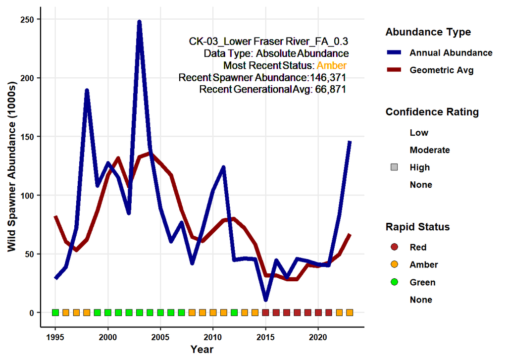

## Timing

### Life History Timing

Timing by life history stage is taken from Wilson and Peacock (2025) [https://cdnsciencepub.com/doi/10.1139/cjfas-2024-0213]. Data quality is rated on a scale of 1 to 6 based on number of observations and their recentness, with 1 being the highest quality data.

Life stage timing throughout the year showing spawning, upstream migration, ocean entry, and juvenile freshwater migration periods. Shaded areas indicate periods used for calculating specific vulnerability indicators. Point size represents data quality (larger = LOWER quality).

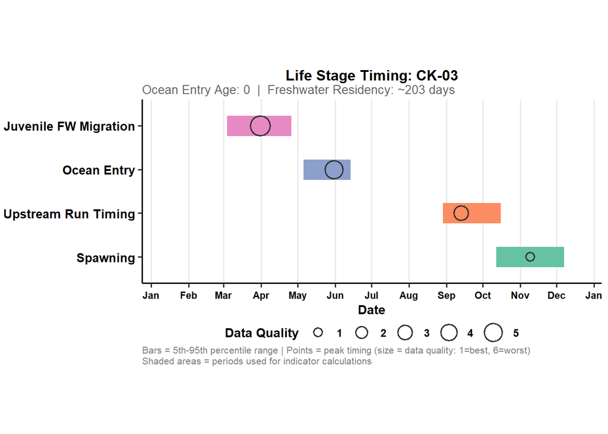

## Spawning & Rearing

### CU Location

Geographic location of the selected conservation unit (green) relative to all Fraser River basin conservation units (grey outlines).

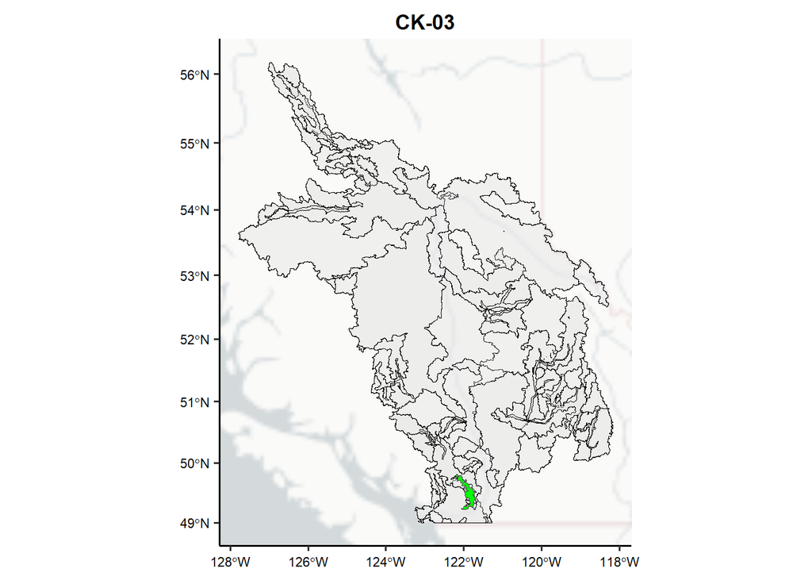

### Stream Access

#### BC FishPass Statistics

Summary statistics for accessible stream habitat within the conservation unit boundary based on BC Fishpass habitat potential models.

**CU Boundary Stream Statistics**

[output not shown]

#### Accessible Stream Network

Accessible streams only with coloring indicating BC Fishpass modelled habitat potential and NuSEDS spawning site locations within the conservation unit boundary.

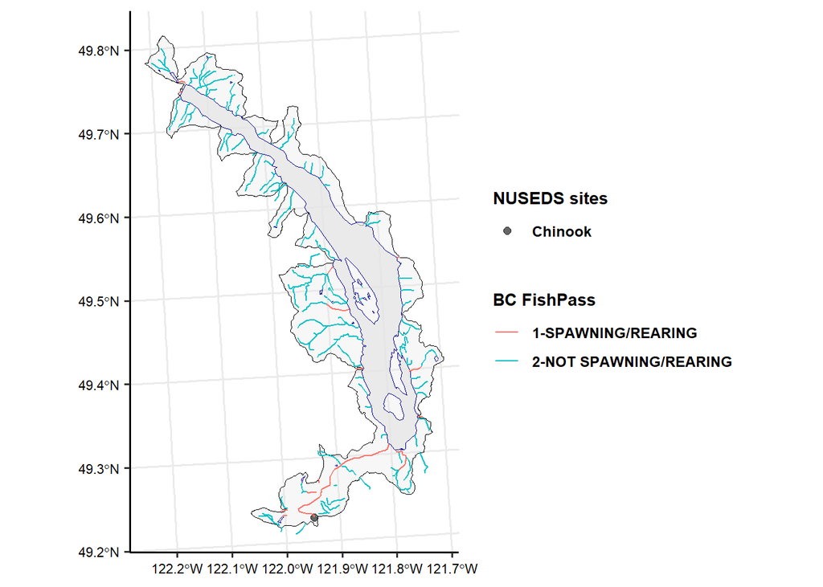

### Hydrology

#### Hydrologic Regime Coverage

Proportion of CU boundary classified by hydrologic regime type using method described in Ruzzante et al 2025. prop_coverage indicates proportion of CU boundary within gauged watersheds.

**Hydrologic Regime Coverage Proportions**

| Snow-Dominated | Rain-Dominated | Hybrid | Glacial | Gauged Coverage |
| --- | --- | --- | --- | --- |
| 0 [1] | 0 [1] | 0.001 [1] | 0.999 [1] | 0.883 [1] |

#### Hydrologic Regime Map

Map of hydrologic regime zones and flow gauge locations within the CU boundary using method described in Ruzzante et al 2025.

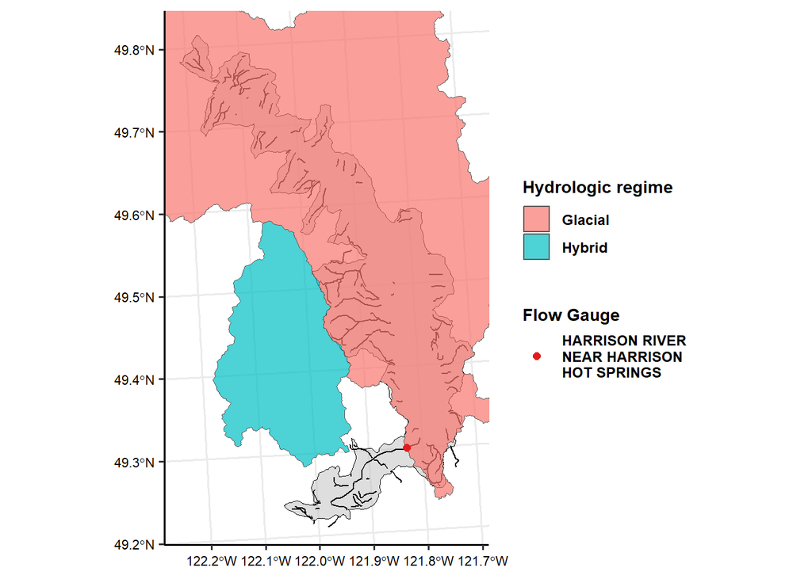

### Flow

#### Flow Indicators Summary

Projected changes in stream flow during the month of August (lowQpdelta) and Nov - Jan (highQpdelta) for RCP 4.5, 2041-2060.

| Indicator Type | Indicator Code | CU score | Species score | All Species score | Mean | Q10 | Q90 | Species Mean | All Species Mean |
| --- | --- | --- | --- | --- | --- | --- | --- | --- | --- |
| Freshwater Spawning and Rearing | lowQpdelta | 0.68777134301501 | 0.468146277645113 | 0.481953071877427 | -0.3926900670941 | -0.645626584367443 | -0.158254811926748 | -0.311088454878177 | -0.317372601020936 |
| Freshwater Spawning and Rearing | highQpdelta | 0.150597061418334 | 0.243388729430408 | 0.242594923525054 | 0.220518823587775 | 0.0458337857521095 | 0.437742840418306 | 0.229865460008731 | 0.240581445152297 |

#### Change in August Flow

Projected proportional change in August stream flows. Negative values indicate flow reductions relative to historic period.

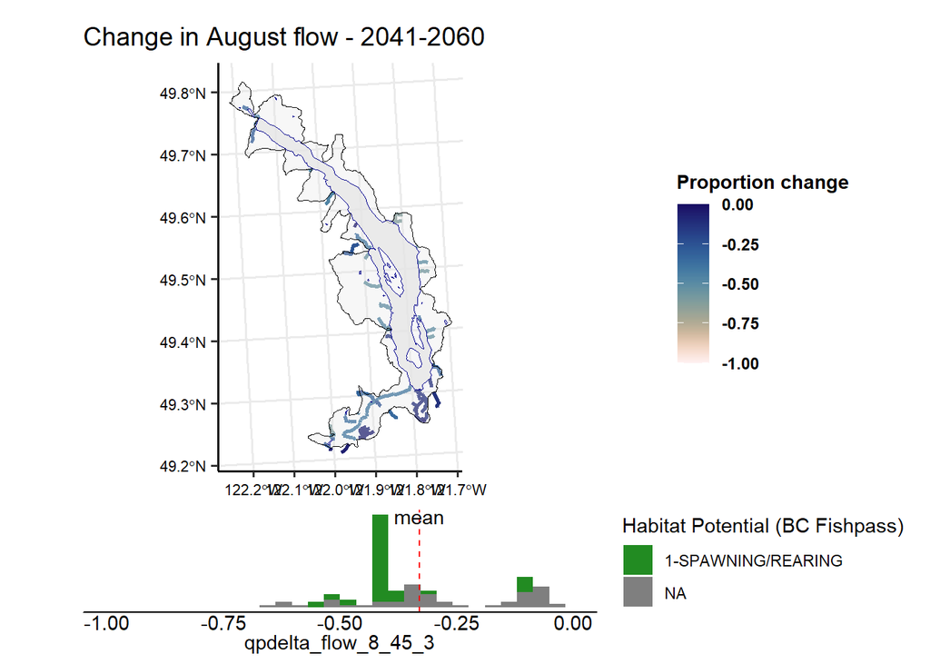

#### Change in Nov-Jan Flow

Projected proportional change in winter flows (November-January). Positive values indicate flow increases relative to historic period.

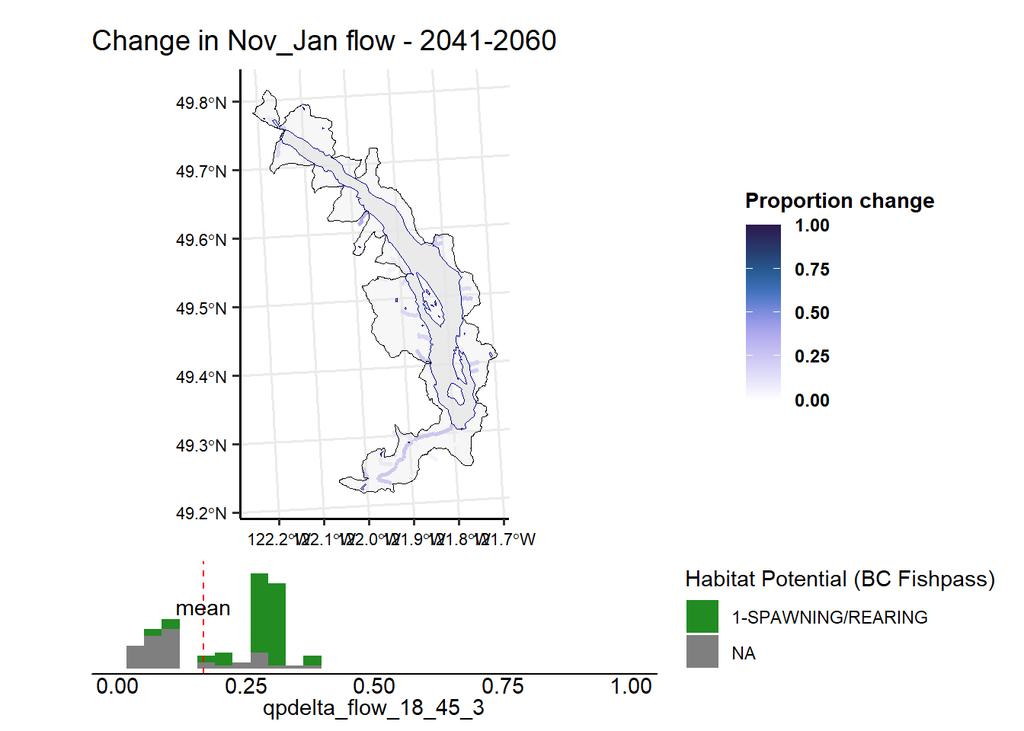

### Temperature

#### Temperature Indicators Summary

Stream temperature indicators: projected August temperature (tw8proj) and rate of change in August temperature (tw8rate).

| Indicator Type | Indicator Code | CU score | Species score | All Species score | Mean | Q10 | Q90 | Species Mean | All Species Mean |
| --- | --- | --- | --- | --- | --- | --- | --- | --- | --- |
| Freshwater Spawning and Rearing | tw8proj | 0.197801920928436 | 0.176716329071034 | 0.163784202653904 | 17.1439386494513 | 16.6208460112938 | 17.6497394170331 | 16.1571427782495 | 15.9556107048002 |
| Freshwater Spawning and Rearing | tw8rate | 0.376108415391892 | 0.522059840726655 | 0.478958724401976 | 0.492453763179364 | 0.40527165681978 | 0.576753891109658 | 0.525095371348869 | 0.515570735747484 |

#### Projected August Stream Temperature

Projected mean August stream temperature (2041-2060, RCP 4.5).

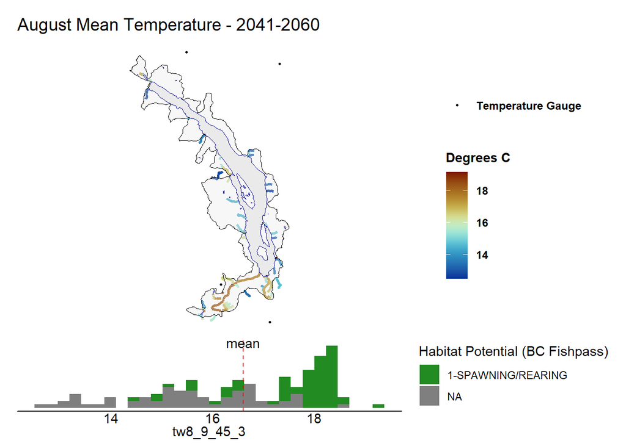

#### Rate of Temperature Change

Rate of change in August stream temperature from baseline (1981-2000) to mid-century (2041-2060).

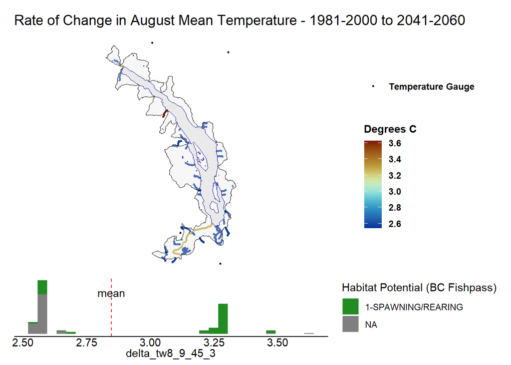

### ENM

#### ENM Indicators Summary

Indicator value of changes in habitat favourability (favchange) from Environmental Niche Models.

| Indicator Type | Indicator Code | CU score | Species score | All Species score | Mean | Q10 | Q90 | Species Mean | All Species Mean |
| --- | --- | --- | --- | --- | --- | --- | --- | --- | --- |
| Freshwater Spawning and Rearing | favchange | 0 | 0.0321392670873897 | 0.133591374000896 | 0.0216523034831287 | NA | NA | 0.0925428024977514 | 0.0402310567733335 |

#### ENM Habitat Favourability

Projected habitat favourability (2041-2060, RCP 4.5). Values range from 0 (unfavourable) to 1 (highly favourable) based on projected environmental conditions.

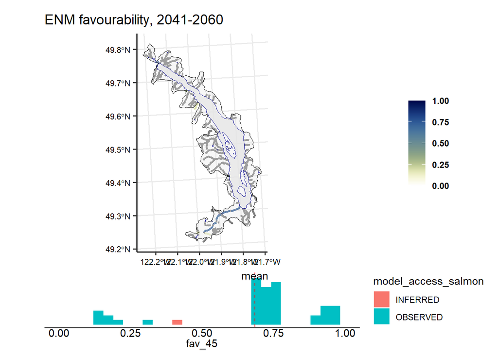

#### Change in Favourability

Change in habitat favourability from baseline to mid-century. Negative values indicate decreased favourability, positive values indicate improving conditions.

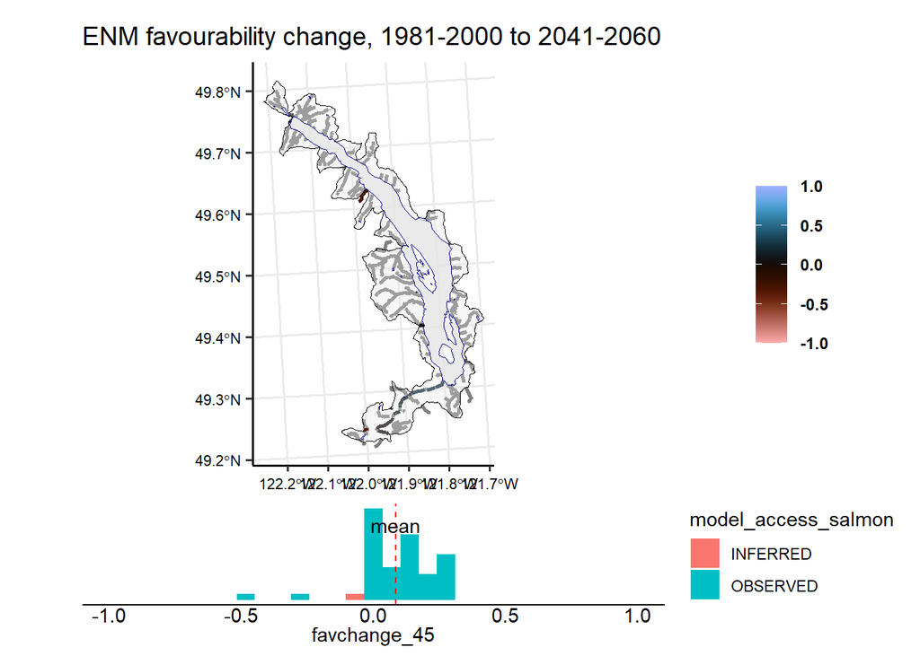

### Threats

#### Cumulative Threats Indicator Summary

Indicator of cumulative threat score (CT) representing anthropogenic stressors to stream habitat.

| Indicator Type | Indicator Code | CU score | Species score | All Species score | Mean | Q10 | Q90 | Species Mean | All Species Mean |
| --- | --- | --- | --- | --- | --- | --- | --- | --- | --- |
| Freshwater Spawning and Rearing | CT | 0.752964549109743 | 0.559652064481243 | 0.543535592328396 | 1.93216304625762 | NA | NA | 1.43610883013145 | 1.41211920717931 |

#### Cumulative Threats to Stream Habitat

Cumulative threat score combining nine anthropogenic stressor categories. Higher values represent higher threats.

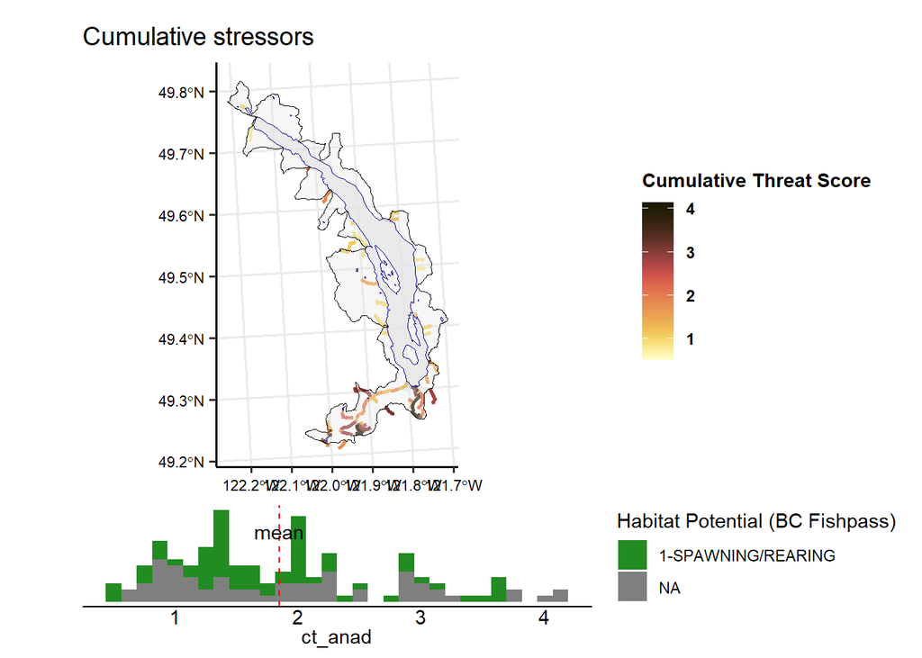

## Migration

### Path

#### Migration Indicators Summary

Indicators representing temperature and flow conditions and migration distance from ocean to spawning grounds.

| Indicator Type | Indicator Code | CU score | Species score | All Species score | Mean | Q10 | Q90 | Species Mean | All Species Mean |
| --- | --- | --- | --- | --- | --- | --- | --- | --- | --- |
| Upstream Migration | migrT | 0 | 0.309489586399105 | 0.321832325760838 | 12.0654280917138 | 11.3550840551447 | 12.9502890033703 | 17.8656813188298 | 16.7783011629389 |
| Upstream Migration | migrQ | NA | NA | NA | -0.188938826779003 | -0.345569548783498 | -0.0338403565606929 | -0.174991042234958 | -0.227384691178029 |
| Upstream Migration | migrdist | 0.0206111957349581 | 0.362562938986206 | NA | 109 | NA | NA | 468.111111111111 | NA |

#### Migration Route

Migration route from river mouth to NuSEDS spawning sites used to calculate indicators, coloured by channel width.

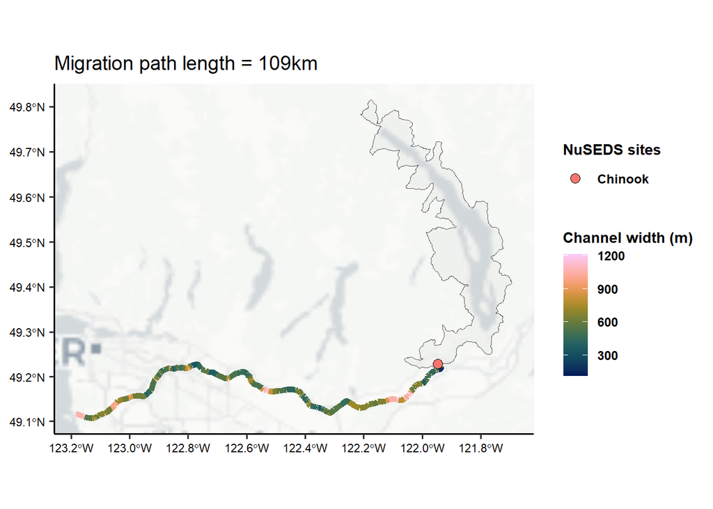

### Timing - Migration

#### Migration Timing and Temperature

Daily projected stream temperatures during upstream migration period. Vertical dashed lines show run timing start/end (blue) and spawn timing start/peak (red). Shaded areas show 10th-90th percentile range across climate models.

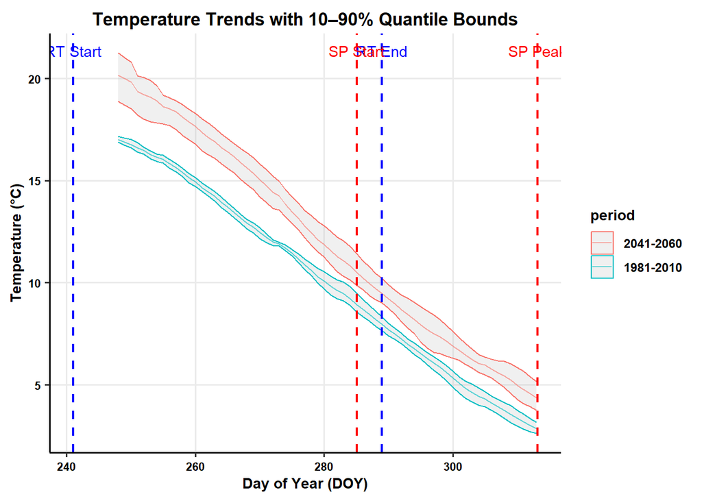

## Marine

### Marine Adaptive Zone

Marine Adaptive Zone (green) representing the nearshore rearing area used for marine indicator calculations.

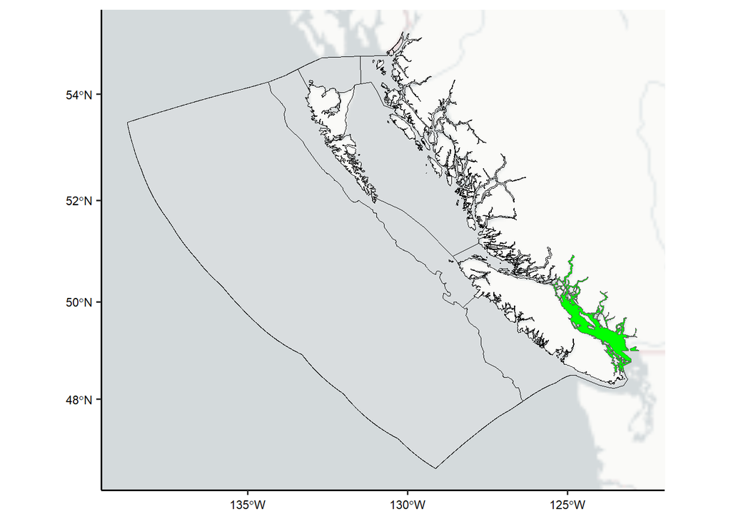

### SST

#### Sea Surface Temperature Indicators Summary

Nearshore marine indicators related to sea surface temperature, the projected SST during the ocean entry period (SSTproj), and the rate of change in SST (SSTrate) relative to the baseline period.

| Indicator Type | Indicator Code | CU score | Species score | All Species score | Mean | Q10 | Q90 | Species Mean | All Species Mean |
| --- | --- | --- | --- | --- | --- | --- | --- | --- | --- |
| Nearshore Marine | SSTproj | 0.209944834677078 | 0.209944834677078 | 0.198963327206084 | 13.1592042561937 | 12.1516736735654 | 14.3217875091413 | 13.1592042561937 | 12.9024015405301 |
| Nearshore Marine | SSTrate | 0.521091314682247 | 0.521091314682247 | 0.504492081716753 | 0.204218262936449 | 0.144692602848468 | 0.259615820873769 | 0.204218262936449 | 0.200898416343351 |

#### Projected Sea Surface Temperature

Projected sea surface temperature during the period surrounding peak ocean entry (2041-2060, RCP 4.5).

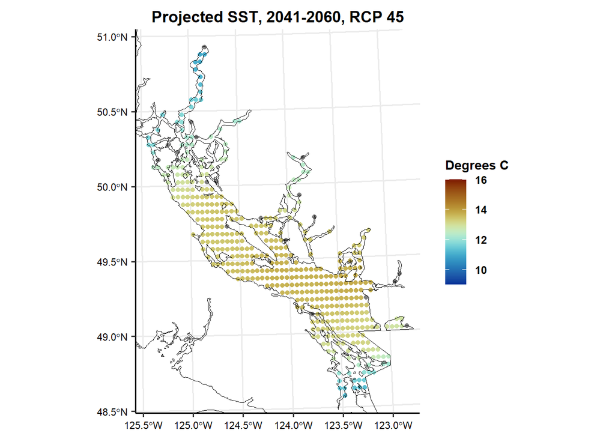

### Impacts

#### Marine Cumulative Impacts Indicator Summary

Indicator for cumulative impact score (CImpact) for nearshore marine habitats within the marine adaptive zone.

| Indicator Type | Indicator Code | CU score | Species score | All Species score | Mean | Q10 | Q90 | Species Mean | All Species Mean |
| --- | --- | --- | --- | --- | --- | --- | --- | --- | --- |
| Nearshore Marine | CImpact | 0.5 | 0.5 | 0.5 | 56.3350999582398 | NA | NA | 56.3350999582398 | 56.3350999582398 |

#### Cumulative Impacts on Marine Habitat

Cumulative impact score combining stressors including aquaculture, fishing, invasive species, pollution, and shipping. Higher values indicate a higher impact score.

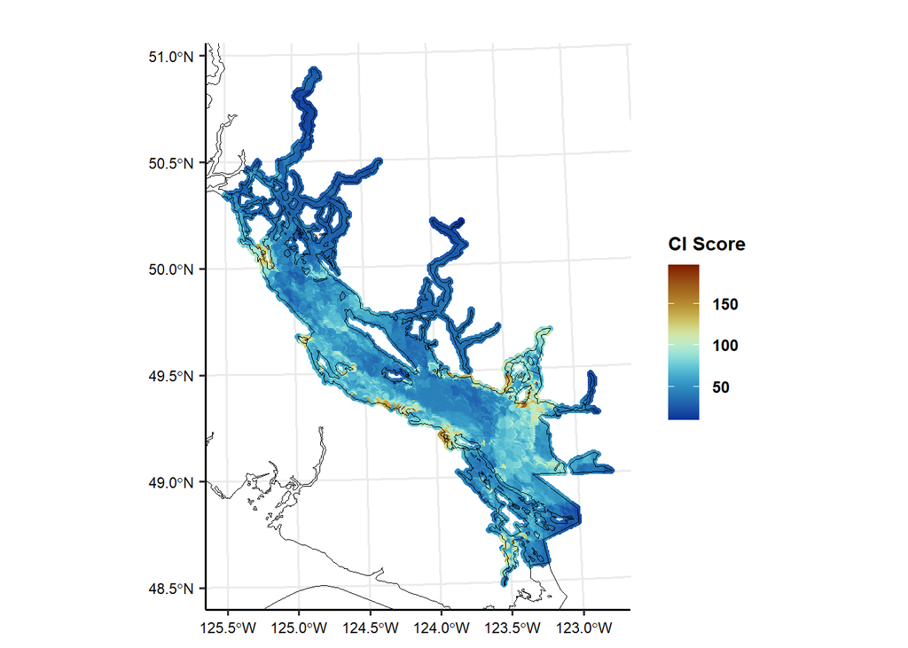